# Portafolio de trabajos Estadistica NRC 1271

Josue Andel Chango Parra

2024-11-26

# TEMARIO DE CLASES

## Introducción a la Estadística: Conceptos fundamentales

La estadística es una rama de las matemáticas que se encarga de recolectar, analizar, interpretar y presentar datos. Los conceptos fundamentales incluyen población, muestra, variable, parámetros y estadísticos

## Medidas de tendencia central y dispersion

### Promedio Muestral

El promedio aritmético o muestral, es la medida de tendencia central más comúnmente utilizada, la cual se define de la siguiente manera:

> Sea $x_1, x_2,\ldots, x_n$ un conjunto de $n$ datos muestrales, entonces, el promedio muestral $\bar{X}$ se obtiene de la siguiente manera:
> $$\bar{X} = \frac{x_1 + x_2 + \ldots
> x_n}{n} = \frac{\sum_{i=1}^{n}x_i }{n}$$

#### Ejemplo:

Los pesos (en kilogramos) de un grupo de cinco atletas son los siguientes

```r
nombres <- c("Atleta 1", "Atleta 2", "Atleta 3", "Atleta 4", "Atleta 5")
pesos <- c(70, 85, 78, 92, 68)

tabla <- as.data.frame(cbind(nombres, pesos))

knitr::kable(t(tabla))
```

| nombres | Atleta 1 | Atleta 2 | Atleta 3 | Atleta 4 | Atleta 5 |
| --- | --- | --- | --- | --- | --- |
| pesos | 70 | 85 | 78 | 92 | 68 |

El promedio muestral del peso (en kilogramos) de este grupo de atletas se calcularía de la siguiente manera:

$$\bar{X} = \frac{70 + 85 + 78 + 92 +
68}{5} = \frac{393}{5} = 78.6$$
Este promedio se puede calcular paso a paso usando **R** de la siguiente manera:

```r
promedio <- (70 + 85 + 78 + 92 + 68)/5
promedio
```

```
## [1] 78.6
```

También es posible calcularlo, utilizando la función *mean*:

```r
pesos <- c(70, 85, 78, 92, 68)
promedio <- mean(pesos)
promedio
```

```
## [1] 78.6
```

La interpretación geométrica del promedio muestral es similar al concepto del centro de gravedad del conjunto de datos: si distribuimos los puntos observados a lo largo del eje horizontal, entonces el promedio muestral se ubica en el punto en el cual se equilibra el “peso” del conjunto de puntos.

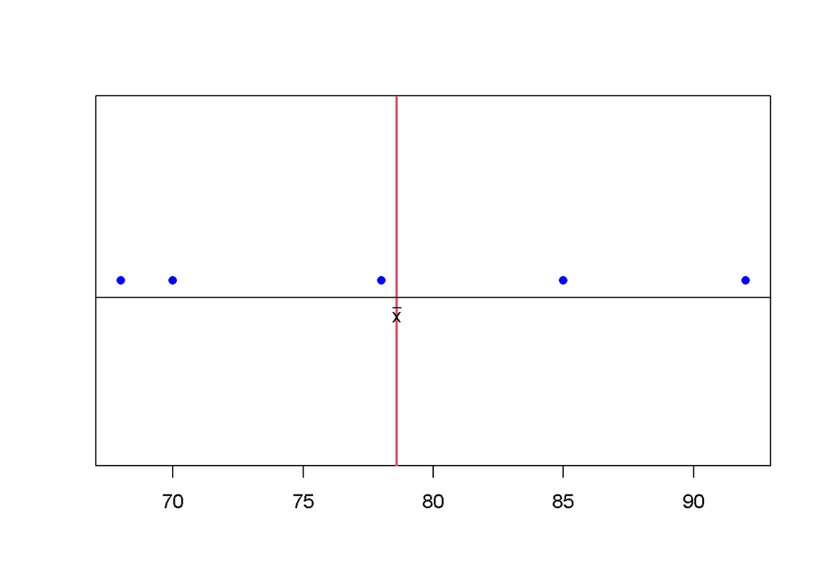

```r
stripchart(pesos, method = "stack", pch=16, col = "blue")
abline(v=78.6, col = 2, lwd = 2)
abline(h=0.9, col = 1, lwd = 1)
text(78.6, 0.8, labels = expression(bar(x)))
```

## Medidas de posicion y forma

## Medidas de posicion y forma

### Mediana

La mediana es el valor que divide un conjunto de datos ordenados en dos partes iguales.

#### Ejemplo:

```r
valores <- c(7, 3, 5, 9, 6)
mediana <- median(valores)
mediana
```

```
## [1] 6
```

### Rango Intercuartil (IQR)

El rango intercuartil es una medida de dispersión que describe el intervalo entre el primer cuartil (Q1) y el tercer cuartil (Q3).

#### Ejemplo:

```r
valores <- c(7, 3, 5, 9, 6)
IQR(valores)
```

```
## [1] 2
```

## Probabilidades: Definiciones y técnicas de conteo

La probabilidad de un evento es un número entre 0 y 1 que indica la posibilidad de que el evento ocurra. La probabilidad se define como:

$$P(A) = \frac{\text{Número de casos
favorables}}{\text{Número de casos posibles}}$$

### Técnica de Conteo: Permutaciones

Las permutaciones se utilizan cuando se desea contar el número de formas en que se pueden ordenar *n* elementos.

#### Ejemplo:

Calcular el número de formas en que se pueden ordenar 4 elementos.

```r
factorial(4)
```

```
## [1] 24
```

## Regla de la adición

La probabilidad de la unión de dos eventos A y B es:

$$P(A \cup B) = P(A) + P(B) - P(A \cap B)$$

#### Ejemplo:

$$\text{Si } \ P(A) = 0.3 \text{ y} \
P(B) = 0.4 \text{ y la probabilidad de que ambos eventos ocurran es } \
P(A \cap B) = 0.1, \text{ entonces: }$$

```r
PA <- 0.3
PB <- 0.4
PAB <- 0.1
P_union <- PA + PB - PAB
P_union
```

```
## [1] 0.6
```

## Probabilidad Condicional

La probabilidad de A dado B es:

$$P(A \mid B) = \frac{P(A \cap
B)}{P(B)}$$

#### Ejemplo

$$\text{Si } P(A \cap B) = 0.1 \text{ y }
P(B) = 0.4, \text{ entonces: }$$

```r
PAB <- 0.1
PB <- 0.4
P_condicional <- PAB / PB
P_condicional
```

```
## [1] 0.25
```

## Regla del producto

La probabilidad de la intersección de dos eventos A y B es:

$$P(A \cap B) = P(A) \cdot P(B \mid A)$$

#### Ejemplo:

$$\text{Si }P(A) = 0.3 \text{ y } P(B \mid
A) = 0.2, \text{ entonces:}$$

```r
PA <- 0.3
PB_A <- 0.2
P_interseccion <- PA * PB_A
P_interseccion
```

```
## [1] 0.06
```

## Tablas de contingencia, Arboles de probabilidad

Una tabla de contingencia es una herramienta para resumir la relación entre varias variables categóricas.

#### Ejemplo:

```r
tabla <- matrix(c(20, 30, 50, 80), nrow = 2, byrow = TRUE)
colnames(tabla) <- c("Categoria 1", "Categoria 2")
rownames(tabla) <- c("Grupo A", "Grupo B")
tabla <- as.table(tabla)
tabla
```

```
##         Categoria 1 Categoria 2
## Grupo A          20          30
## Grupo B          50          80
```

## Regla de probabilidad Total

La probabilidad total de un evento es la suma de las probabilidades de los eventos que componen el evento total.

#### Ejemplo:

> Sea $A_1, A_2,\ldots, A_n$ son eventos disjuntos, entonces:
> $$P(B) =
> \sum_{i=1}^{n} P(B \mid A_i) P(A_i)$$

```r
PA1 <- 0.2
PA2 <- 0.3
PB_A1 <- 0.5
PB_A2 <- 0.4
P_total <- PB_A1 * PA1 + PB_A2 * PA2
P_total
```

```
## [1] 0.22
```

## Teorema de Bayes

El teorema de Bayes relaciona la probabilidad condicional y las probabilidades marginales de eventos aleatorios:

$$P(A \mid B) = \frac{P(B\mid
A)P(A)}{P(B)}$$

```r
PA <- 0.3
PB_A <- 0.2
PB <- 0.4
P_Bayes <- (PB_A * PA) / PB
P_Bayes
```

```
## [1] 0.15
```

## Variables aleatorias discretas y continuas

### Distribución Binomial

La distribución binomial describe el número de éxitos en una secuencia de *n* ensayos de Bernoulli.

#### Ejemplo:

Si lanzamos una moneda 10 veces, ¿cuál es la probabilidad de obtener exactamente 6 caras?

```r
n <- 10
p <- 0.5
x <- 6
prob_binomial <- choose(n, x) * p^x * (1-p)^(n-x)
prob_binomial
```

```
## [1] 0.2050781
```

## Distribucion Uniforme

La distribución uniforme continua se define por dos parámetros **A** y **B**, que representan los límites inferior y superior del intervalo.

#### Ejemplo:

Si una variable aleatoria tiene una distribución uniforme entre 7 y 10, ¿cuál es la probabilidad de que tome un valor menor a 8.5?

```r
A <- 7
B <- 10
P_uniforme <- (8.5 - A) / (B - A)
P_uniforme
```

```
## [1] 0.5
```

## Distribucion Normal

La distribución normal es una distribución de probabilidad continua simétrica que se describe con dos parámetros: la media *μ* y la desviación estándar *σ*.

#### Ejemplo:

Si una variable aleatoria sigue una distribución normal con media **μ=0** y desviación estándar **σ=1**, ¿cuál es la probabilidad de que la variable tome un valor menor a 1.96?

```r
mu <- 0
sigma <- 1
x <- 1.96
p <- pnorm(x, mean = mu, sd = sigma)
p
```

```
## [1] 0.9750021
```

### Grafico de la distribucion normal:

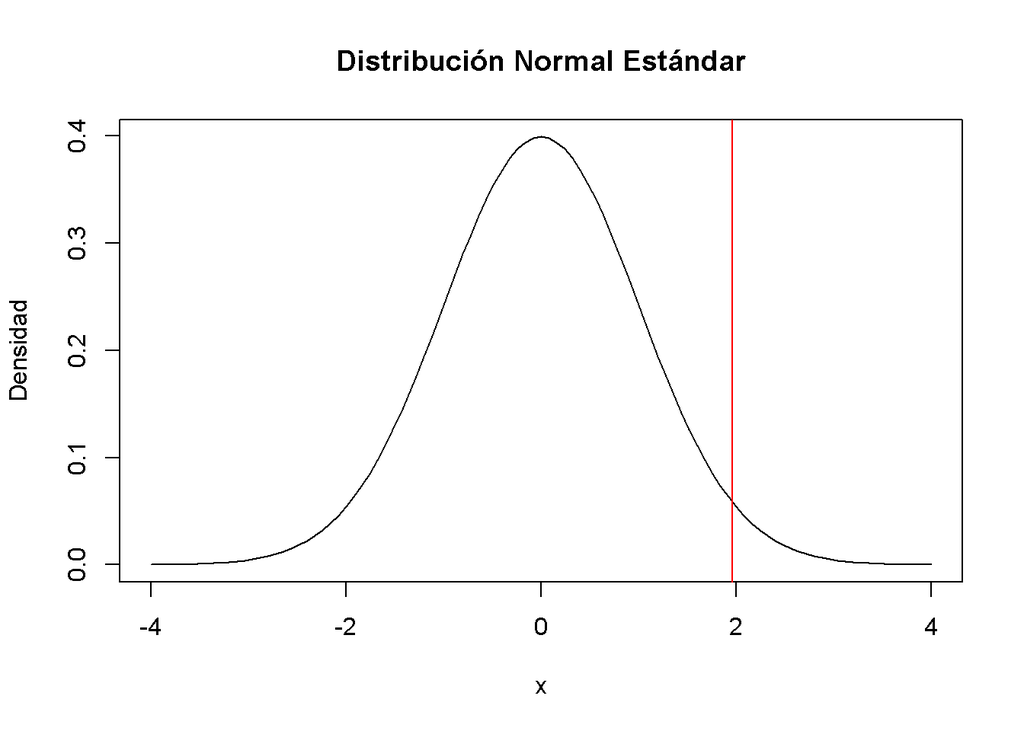

```r
curve(dnorm(x, mean = mu, sd = sigma), from = -4, to = 4, main = "Distribución Normal Estándar", ylab = "Densidad")
abline(v = x, col = "red")
```

## Esperanza Matematica

La esperanza matemática (o valor esperado) de una variable aleatoria *X* es el promedio ponderado de todos los valores posibles que *X* puede tomar.

$$E(X) = \sum_{i=1}^{n} x_i P(x_i)$$

#### Ejemplo:

Si una variable aleatoria discreta *X* toma los valores 1, 2, y 3 con probabilidades 0.2, 0.5, y 0.3 respectivamente, la esperanza matemática es:

#### Manual:

$$E(X) = 1 \cdot 0.2 + 2 \cdot 0.5 + 3
\cdot 0.3 = 2.1$$

#### En *R*

```r
valores <- c(1, 2, 3)
probabilidades <- c(0.2, 0.5, 0.3)
esperanza <- sum(valores * probabilidades)
esperanza
```

```
## [1] 2.1
```

## Varianza

La varianza de una variable aleatoria *X* es la esperanza del cuadrado de su desviación respecto a su media.

$$\text{Var}(X) = E[(X - E(X))^2]$$

#### Ejemplo:

Usando los valores y probabilidades del ejemplo anterior:

#### Manual:

$$\text{Var}(X) = (1 - 2.1)^2 \cdot 0.2 +
(2 - 2.1)^2 \cdot 0.5 + (3 - 2.1)^2 \cdot 0.3 = 0.49$$

#### En *R*

```r
esperanza <- 2.1
varianza <- sum((valores - esperanza)^2 * probabilidades)
varianza
```

```
## [1] 0.49
```

## Distribuciones Discretas: Bernoulli

La distribución Bernoulli describe un experimento binario (éxito o fracaso) con probabilidad de éxito *p*.

#### Ejemplo:

Simularemos datos de una variable que sigue una distribución de Bernoulli. Supongamos que realizamos 150 experimentos donde la probabilidad de éxito es 0.6. Queremos calcular la media de los resultados y visualizar la frecuencia de éxitos y fracasos.

```r
# Simulación de datos de una distribución de Bernoulli
set.seed(123)  # Establecemos una semilla para reproducibilidad
n <- 150        # Número de experimentos
p <- 0.6        # Probabilidad de éxito

# Generar los datos
datos_bernoulli <- rbinom(n, 1, p)

# Calcular la media de los datos
media <- mean(datos_bernoulli)
cat("La media de la distribución de Bernoulli es:", media, "\n")
```

```
## La media de la distribución de Bernoulli es: 0.5933333
```

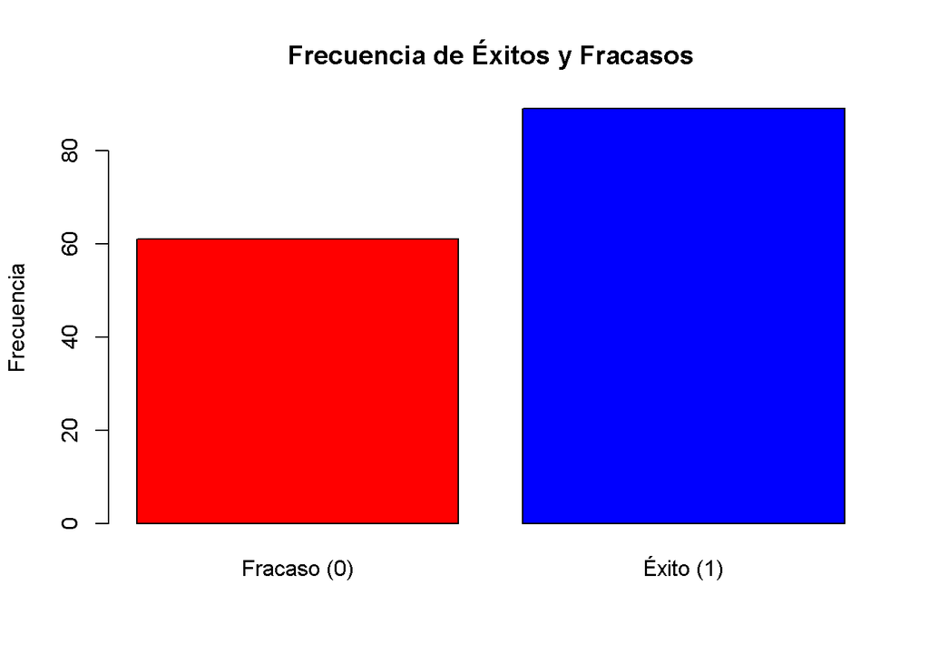

```r
# Crear un gráfico de barras
barplot(table(datos_bernoulli), col = c("red", "blue"),
        names.arg = c("Fracaso (0)", "Éxito (1)"),
        main = "Frecuencia de Éxitos y Fracasos",
        ylab = "Frecuencia")
```

## Distribucion Binomial

La distribución binomial describe el número de éxitos en *n* ensayos de Bernoulli.

#### Ejemplo:

En este ejemplo, simularemos datos de una variable que sigue una distribución binomial. Supongamos que realizamos 200 ensayos donde la probabilidad de éxito en cada ensayo es 0.3. Queremos calcular la media, la varianza y visualizar la distribución de los resultados.

```r
# Simulación de datos de una distribución binomial
set.seed(456)  # Establecemos una semilla para reproducibilidad
n <- 200        # Número total de ensayos
p <- 0.3        # Probabilidad de éxito en cada ensayo

# Generar los datos
datos_binomial <- rbinom(n, size = 1, prob = p)

# Calcular la media y la varianza de los datos
media <- mean(datos_binomial)
varianza <- var(datos_binomial)
cat("La media de la distribución binomial es:", media, "\n")
```

```
## La media de la distribución binomial es: 0.36
```

```r
cat("La varianza de la distribución binomial es:", varianza, "\n")
```

```
## La varianza de la distribución binomial es: 0.2315578
```

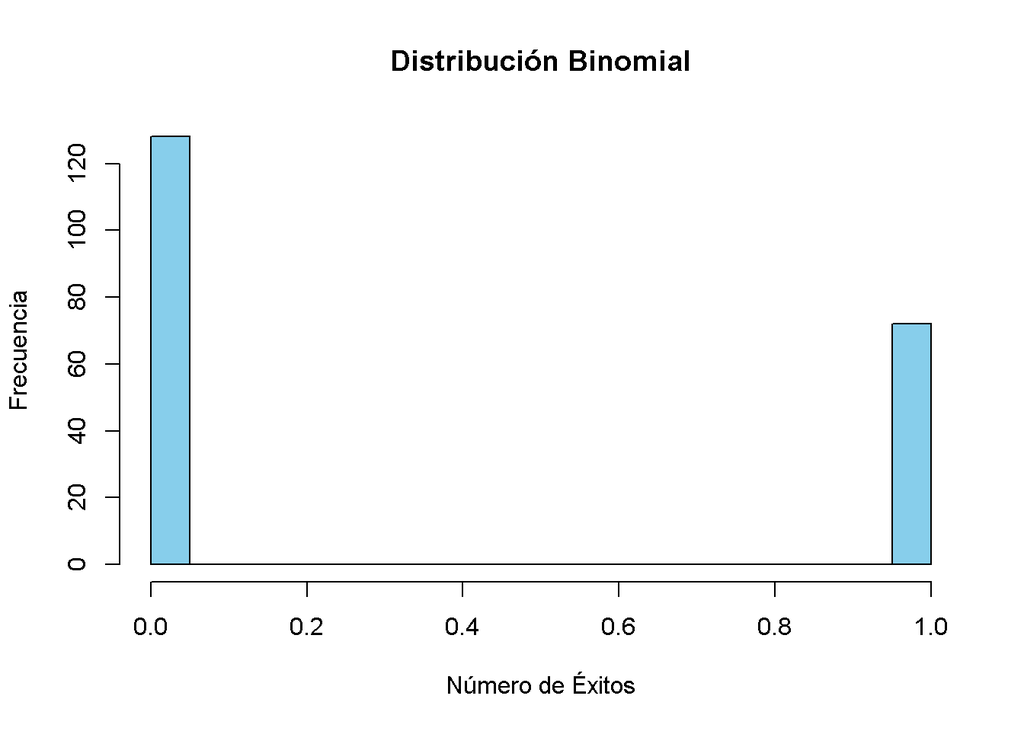

```r
# Crear un histograma de los datos
hist(datos_binomial, breaks = 20, col = "skyblue",
     main = "Distribución Binomial",
     xlab = "Número de Éxitos",
     ylab = "Frecuencia")
```

## Distribucion de Poisson

La distribución de Poisson describe el número de eventos en un intervalo fijo de tiempo o espacio.

#### Ejemplo:

Si el número de llamadas por hora es una variable aleatoria de Poisson con λ=6, ¿cuál es la probabilidad de recibir exactamente 4 llamadas en una hora?

#### Manual:

Usando la fórmula de la distribución de Poisson:

$$P(X=4) = \frac{\lambda^4
e^{-\lambda}}{4!} = 0.1339$$

#### En *R*:

```r
#Usando la formula directa

lambda = 6

p4 = exp(-lambda)*lambda^4 / factorial(4)
p4
```

```
## [1] 0.1338526
```

```r
#Usando la funcion 'dpois()' en R

lambda = 6
x = 4
prob_poisson = dpois(x, lambda)
prob_poisson
```

```
## [1] 0.1338526
```

## Aplicaciones de la Distribución Normal: Aproximación a la Binomial

> Cuando $n$ es grande, la distribución binomial $B(n,p)$ se puede aproximar con una distribución normal $N(np, \sqrt{np(1-p)})$.

#### Ejemplo:

Para n = 100 y p = 0.5, calcular la probabilidad de obtener entre 45 y 55 éxitos.

#### Manual:

Aproximacion usando la normal:

$$\mu = np = 100 \cdot 0.5 = 50$$
$$\sigma = \sqrt{np(1-p)} =
\sqrt{100 \cdot 0.5 \cdot 0.5} = 5$$

#### En *R*:

```r
n <- 100
p <- 0.5
mu <- n * p
sigma <- sqrt(n * p * (1 - p))
prob <- pnorm(55, mean = mu, sd = sigma) - pnorm(45, mean = mu, sd = sigma)
prob
```

```
## [1] 0.6826895
```

# RESOLUCION DE EJERCICIOS PROPUESTOS

# Ejercicios de resolucion manual

## 1

Los datos siguientes representan los pesos de los recien nacidos en un hospital de una gran ciudad del este de Estados Unidos.

```r
Pesos = c(2.4, 3.3, 4.1,5.0,5.1,5.2,5.6,5.8,5.9,5.9,6.0,6.1,6.2,6.3,6.3,6.4,6.4,6.5,6.7,6.8,7.2,7.4,7.5,7.5,7.6,7.6,7.7,7.8,7.8,7.9,7.9,8.3,8.5,8.8,9.2,9.7,9.8,9.9,10.0,10.3,10.5)
```

### (A) Represéntelos gráficamente mediante un diagrama de tallos y hojas.

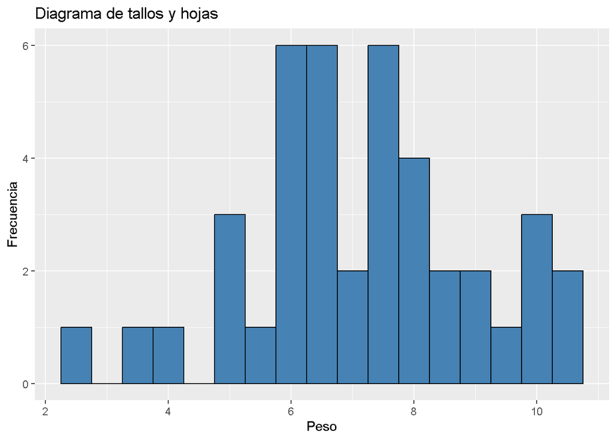

```r
library(ggplot2)
datos <- c(2.4, 3.3, 4.1, 5.0, 5.1, 5.2, 5.6, 5.8, 5.9, 5.9, 6.0, 6.1, 6.2, 6.3,
          6.3, 6.4, 6.4, 6.5, 6.7, 6.8, 7.2, 7.4, 7.5, 7.5, 7.6, 7.6, 7.7, 7.8,
          7.8, 7.9, 7.9, 8.3, 8.5, 8.8, 9.2, 9.7, 9.8, 9.9, 10.0, 10.3, 10.5)
ggplot(data.frame(value = datos), aes(value)) +
  geom_histogram(binwidth = 0.5, fill = "steelblue", color = "black") +
  labs(title = "Diagrama de tallos y hojas", x = "Peso", y = "Frecuencia")
```

La media muestral se calcula sumando todos los valores y dividiendo entre el número total de datos:

$\bar{x} = \frac{\sum_{i=1}^{n} x_i}{n}$

Para calcular la mediana, primero ordenamos los datos de menor a mayor:

2.4, 3.3, 4.1, 5.0, 5.1, 5.2, 5.6, 5.8, 5.9, 5.9, 6.0, 6.1, 6.2, 6.3, 6.3, 6.4, 6.4, 6.5, 6.7, 6.8, 7.2, 7.4, 7.5, 7.5, 7.6, 7.6, 7.7, 7.8, 7.8, 7.9, 7.9, 8.3, 8.5, 8.8, 9.2, 9.7, 9.8, 9.9, 10.0, 10.3, 10.5

### (D) Calcular la desviación típica muestral $s$

$\sqrt{\frac{\sum_{i=1}^{n} (x_i-\hat{x})^2 }{n-1}}$

Donde $\bar{x}$ es la media muestral calculada anteriormente.

Desarrollando el cálculo:

$$s = \sqrt{\frac{13.7225 + 8.8225 +
\ldots + 16.3225}{39}}$$

$$s =
\sqrt{\frac{1311.1}{39}}$$

$$s = \sqrt{33.6}$$

### (E) Calcular la proporción de valores de datos comprendidos entre $\bar{x} \pm 2s$

Los valores comprendidos entre $-5.485$ y $17.715$ son: 2.4, 3.3, 4.1, 5.0, 5.1, 5.2, 5.6, 5.8, 5.9, 5.9, 6.0, 6.1, 6.2, 6.3, 6.3, 6.4, 6.4, 6.5, 6.7, 6.8, 7.2, 7.4, 7.5, 7.5, 7.6, 7.6, 7.7, 7.8, 7.8, 7.9, 7.9, 8.3, 8.5, 8.8, 9.2, 9.7, 9.8, 9.9, 10.0, 10.3, 10.5

### (F) Los datos parecen ser aproximadamente normales

Sí, los datos parecen ser aproximadamente normales, ya que la mayoría de los valores se encuentran dentro de $\bar{x} \pm 2s$, lo cual es característico de una distribución normal.

## 2

Una cafetería ofrece un menú con tres platos. Se puede elegir un plato principal, un complemento y un postre. Las elecciones posibles de cada uno son las siguientes

```r
library(knitr)
library(kableExtra)

# Crear los datos
menu <- data.frame(
  Menú = c("Plato principal", "Complemento", "Postre"),
  Elección = c("Pollo o filete", "Pasta, arroz o patata", "Helado, gelatina o tarta de manzana")
)

# Generar la tabla con formato
kable(menu, align = 'l', col.names = c("Menú", "Elección")) %>%
  kable_styling(full_width = F, bootstrap_options = c("striped", "hover", "condensed", "responsive"))
```

| Menú | Elección |
| --- | --- |
| Plato principal | Pollo o filete |
| Complemento | Pasta, arroz o patata |
| Postre | Helado, gelatina o tarta de manzana |

Cada individuo debe elegir un elemento de cada categoría.

### (A) Liste todos los resultados del espacio muestral $S$.

Los resultados del espacio muestral $S$ son:

$$(Pollo, Pasta, Helado), (Pollo, Pasta,
Gelatina), (Pollo, Pasta, Tarta de manzana),$$
$$(Pollo, Arroz, Helado), (Pollo, Arroz, Gelatina),
(Pollo, Arroz, Tarta de manzana),$$
$$(Pollo, Patata, Helado), (Pollo, Patata,
Gelatina), (Pollo, Patata, Tarta de manzana),$$
$$(Filete, Pasta, Helado), (Filete, Pasta,
Gelatina), (Filete, Pasta, Tarta de manzana),$$
$$(Filete, Arroz, Helado), (Filete, Arroz,
Gelatina), (Filete, Arroz, Tarta de manzana),$$
$$(Filete, Patata, Helado), (Filete, Patata,
Gelatina), (Filete, Patata, Tarta de manzana)$$

### (B) Si A es el suceso consistente en que se elija helado, liste los resultados de A.

El suceso A es “elegir helado como postre”. Los resultados de A son:

$$(Pollo, Pasta, Helado), (Pollo, Arroz,
Helado), (Pollo, Patata, Helado),$$
$$(Filete, Pasta, Helado), (Filete, Arroz, Helado),
(Filete, Patata, Helado)$$

### (C) Si B es el suceso consistente en que se elija pollo, liste los resultados de B.

El suceso B es “elegir pollo como plato principal”. Los resultados de B son:

$$(Pollo, Pasta, Helado), (Pollo, Pasta,
Gelatina), (Pollo, Pasta, Tarta de manzana),$$
$$(Pollo, Arroz, Helado), (Pollo, Arroz, Gelatina),
(Pollo, Arroz, Tarta de manzana),$$
$$(Pollo, Patata, Helado), (Pollo, Patata,
Gelatina), (Pollo, Patata, Tarta de manzana)$$

### (D) Liste todos los resultados de $A ∩ B$.

$A ∩ B$ es el suceso “elegir pollo como plato principal y helado como postre”. Los resultados son:

$$(Pollo, Pasta, Helado), (Pollo, Arroz,
Helado), (Pollo, Patata, Helado)$$

### (E) Si $C$ es el suceso consistente en que se elija arroz, liste los resultados de $C$.

El suceso $C$ es “elegir arroz como complemento”. Los resultados de $C$ son:

$$(Pollo, Arroz, Helado), (Pollo, Arroz,
Gelatina), (Pollo, Arroz, Tarta de manzana),$$
$$(Filete, Arroz, Helado), (Filete, Arroz,
Gelatina), (Filete, Arroz, Tarta de manzana)$$

### (F) Liste todos los resultados del suceso $A ∩ B ∩ C$.

$A ∩ B ∩ C$ es el suceso “elegir pollo como plato principal, arroz como complemento y helado como postre”. Los resultados son:

$$(Pollo, Arroz, Helado)$$

## 3

Las soldaduras de juntas tubulares pueden tener dos tipos de defectos, que se denominarán $A$ y $B$. Cada soldadura puede tener el defecto $A$ con probabilidad $0,064$, y el defecto $B$ con probabilidad $0.043$, y ambos defectos con probabilidad $0.025$. Encuentre la proporción de soldaduras que:

### (B) No tienen defecto alguno.

Para calcular la proporción de soldaduras que no tienen ningún defecto, debemos encontrar la probabilidad complementaria de tener al menos un defecto.

Probabilidad de tener al menos un defecto: $0.064 + 0.043 - 0.025 = 0.082$ Probabilidad de no tener ningún defecto: $1 - 0.082 = 0.918$

Por lo tanto, la proporción de soldaduras que no tienen defecto alguno es $0.918$ o $91.8\%$.

## 4

Los pozos de petróleo perforados en la región A tienen una probabilidad de $0.2$ de producir. Los pozos perforados en la región B tienen una probabilidad de $0.09$. Se perfora un pozo en cada región. Suponga que los pozos producen de manera independiente.

### (A) ¿Cuál es la probabilidad de que ambos pozos produzcan?

Probabilidad de que ambos pozos produzcan $= 0.2 × 0.09 = 0.018$ o $1.8\%$

### (B) ¿Cuál es la probabilidad de que ninguno produzca?

Probabilidad de que ninguno produzca $= (1-0.2) × (1-0.09) = 0.728$ o $72.8\%$

### (C) ¿Cuál es la probabilidad de que al menos uno produzca?

Probabilidad de que al menos uno produzca $= 1 - 0.728 = 0.272$ o $27.2\%$

## 5

De todas las fallas de un tipo determinado de unidad de disco duro de computadora, se determina que $20\%$ de éstos tiene dañado sólo el sector que contiene la tabla de asignación de archivos, en $70\%$ sólo los sectores no esenciales están dañados y en $10\%$ tanto el sector de asignación como uno o más sectores no esenciales están dañados. Se selecciona aleatoriamente una unidad de disco dañada y se examina.

### (A) ¿Cuál es la probabilidad de que el sector de asignación esté dañado?

$P(L)$ $+$ $P(L$^$S)$ $-> 0.20 + 0.1 = 0.30$

### (C) Si se encuentra que la unidad de disco tiene un sector de asignación dañado, ¿cuál es la probabilidad de que algunos sectores no esenciales también estén dañados?

$P(L|S) = \frac{P(L S)}{P(L U (L S))} = \frac{0.1}{0.3} = 0.33$

##6 Un sistema de aspersión automático especial tiene dos tipos diferentes de dispositivos de activación para cada regadera. Un tipo tiene una confiabilidad de $0,9$; es decir. la probabilidad de que se active cuando debe el aspersor es $0.9$. EI otro tipo, que opera independientemente del primer tipo, tiene una confiabilidad de $0.8$. Si se dispara cualquier dispositivo, el aspersor se activará. Suponga que empieza un fuego cerca de una regadera.

### (A) ¿Cuál es la probabilidad de que la regadera se active?

Dispositivos se operan de manera distinta (independientes), por tanto Probabilidad de que la regadera se active $1 - (1 - 0.9) × (1 - 0.8) = 0.98$

### (B) ¿Cuál es la probabilidad de que la regadera no se active?

Probabilidad de que la regadera no se active $1 - 0.98 = 0.02$

### (C) ¿Cuál es la probabilidad de que ambos dispositivos de activación trabajen adecuadamente?

Dispositivos operan de manera independiente Probabilidad de que ambos dispositivos trabajen adecuadamente $0.9 × 0.8 = 0.72$

### (D) ¿Cuál es la probabilidad de que solo el dispositivo con 0.9 de confiabilidad trabaje adecuadamente?

Dispositivos operan de manera independiente Probabilidad de que el dispositivo con $0.8$ falle es $1 - 0.8 = 0.2$ Probabilidad de que solo el dispositivo con $0.9$ trabaje adecuadamente $0.9 × 0.2 = 0.18$

## 9

### (A) ¿Cuál es la probabilidad de que la persona elegida esté a favor de que se suspenda la política de alquileres?

Probabilidad de que sea republicana y esté a favor $0.52 × 0.64 = 0.3328$

Probabilidad de que sea demócrata y esté a favor $0.48 × 0.42 = 0.2016$

Probabilidad total de que la persona elegida esté a favor $0.3328 + 0.2016 = 0.5344$

## 10

### (A) ¿Cuál es la probabilidad de que el marido gane menos de $75 000 $ $?

Probabilidad de que el marido gane menos de $75 000 \$ -> 212 / 500 = 0.424$

### (B) Si el marido gana más de $75 000 \$$, ¿cuál es la probabilidad condicionada de que la esposa gane más de esta cantidad?

La probabilidad condicionada de que la esposa gane más de $75 000 \$$ si el marido gana más de esta cantidad es:

Probabilidad condicionada $-> \frac{54}{54} = 1$

### (C) Si el marido gana menos de $75 000 \$$, ¿cuál es la probabilidad condicionada de que la esposa gane más de esta cantidad?

La probabilidad condicionada de que la esposa gane más de $75 000 \$$ si el marido gana menos de esta cantidad es:

Probabilidad condicionada $-> \frac{36}{212} = 0.1698$

### (D) ¿Los salarios de la esposa y el marido son independientes?

No, los salarios de la esposa y el marido no son independientes, porque se condicionan.

## 11

Cierto tipo de componente está empaquetado en lotes de cuatro. Sea $X$ el número de componentes que funcionan de modo adecuado en un lote elegido de manera aleatoria. Suponga que la probabilidad de que evwtamente $x$ componentes funcionen es proporcional a $x$; en otras palabras. suponga que la función de masa de probabilidad de $X$ es dada por:
$$p(x) =
\begin{cases}
cx & x = 1, 2, 3, 4, \\
0 & \text{de otro modo}.
\end{cases}$$
donde c es una constante.

### (A) Determinar el valor de la constante c para que p(x) sea una función de masa de probabilidad.

Para que $p(x)$ sea una función de masa de probabilidad, debe cumplir que:

$p(x) ≥ 0$ para todo $x$

$\sum p(x) = 1$ (la suma de las probabilidades debe ser igual a 1) Reemplazando en la función dada:

$p(x) = cx$, para $x = 1, 2, 3, 4$

$p(x) = 0$, para cualquier otro valor de $x$

Aplicando la condición $2$:

$\sum p(x) = c(1 + 2 + 3 + 4) = c * 10 = 1$

$c = 1/10 = 0.1$

Por lo tanto, el valor de la constante $c$ es $0.1$.

### (B) Determinar $P(X = 2)$.

Reemplazando en la función de masa de probabilidad:

$P(X = 2) = c * 2 = 0.1 * 2 = 0.2$

### (C) Determinar la media del número de componentes que funcionan adecuadamente.

La media de una variable aleatoria discreta $X$ se calcula como:

$E[X] = \sum x * p(x)$

### (D)Determinar la varianza del número de componentes que funcionan adecuadamente.

La varianza de una variable aleatoria discreta $X$ se calcula como:

$V(X) = \sum (x - E[X])^2 * p(x)$

## 12

Las partículas son un componente muy importante de la contaminación atmosférica en muchas áreas. Es interesante estudiar los tamaños de las partículas contaminantes. Sea $x$ el diámetro, en micrómetros, de una panícula elegida aleatoriamente. Suponga que en cierta área. la función de densidad de probabilidad de $X$ es inversamente proporcional al volumen de la partícula; es decir, suponga que:

$$f(x) =
\begin{cases}
\frac{c}{x^3} & x \geq 1 \\
0 & x<1.
\end{cases}$$
donde $c$ es una constante.

### (A) Determinar el valor de $c$ para que $f(x)$ sea una función de densidad de probabilidad.

Para que $f(x)$ sea una función de densidad de probabilidad, debe cumplir que:

$f(x) \geq 0$ para todo $x$ $\int f(x) dx = 1$ (el área bajo la curva debe ser igual a 1) Reemplazando en la función dada:

$f(x) = \frac{c}{x^3}$, para $x \geq 1$ $f(x) = 0$, para $0 \geq x < 1$

Aplicando la condición $2$:

$\int f(x) dx = \int (\frac{c}{x^3}) dx = c \int (\frac{1}{x^3}) dx = c * (\frac{-1}{2x^2}) |_1^\infty = c * (\frac{-1}{2} + \frac{1}{2}) = c$

### (B) Determinar la media del diámetro de la partícula.

La media de una variable aleatoria continua $x$ se calcula como:

$E[X] = \int x * f(x) dx$

Reemplazando:

$E[X] = \int x * (\frac{1}{x^3}) dx = \int (\frac{1}{x^2}) dx = \frac{-1}{x} |_1^\infty = \frac{-1}{1} + \frac{1}{\infty} = 2$

Por lo tanto, la media del diámetro de la partícula es $2$ micrómetros.

### (C) Determinar la función de distribución acumulativa del diámetro de la partícula.

La función de distribución acumulativa de una variable aleatoria continua $x$ se calcula como:

$F(x) = \int f(t) dt$, para $t \leq x$

Reemplazando:

$F(x) = \int (\frac{1}{t^3}) dt = \frac{-1}{2t^2} |_1^x = \frac{-1}{2x^2} + \frac{1}{2}$, para $x \geq 1$

$F(x) = 0$, para $0 \leq x < 1$

### (D) Determinar la mediana del diámetro de la partícula.

La mediana es el valor de $x$ tal que $F(x) = 0.5$. Resolviendo la ecuación:

$\frac{-1}{2x^2} + \frac{1}{2} = 0.5$

$x^2 = 2$ $x = \sqrt{2} \approx 1.41$ micrómetros

### 13

La tabla siguiente presenta la función de masa de probabilidad del número de defectos $x$ en un tablero de circuitos impresos elegido aleatoriamente.

$$\begin{array}{|c|c|c|c|c|}
\hline
x & 0 & 1 & 2 & 3 \\ \hline
p(x) & 0.5 & 0.3 & 0.1 & 0.1 \\ \hline
\end{array}$$

### (A) Determinar $P(x < 2)$.

De la tabla de probabilidades, se tiene que:

$P(x = 0) = 0.5$

$P(x = 1) = 0.3$

$P(x = 2) = 0.1$

Por lo tanto, la probabilidad de que el número de defectos sea menor a $2$ es:

$P(x < 2) = P(x = 0) + P(x = 1) = 0.5 + 0.3 = 0.8$

### (B) Determinar P(X ≥ 1).

La probabilidad de que el número de defectos sea mayor o igual a 1 es:

$P(x \geq 1) = P(x = 1) + P(x = 2) + P(x = 3) = 0.3 + 0.1 + 0.1 = 0.5$

## (C) Determinar $/mu$ x.

La media o valor esperado de una variable aleatoria discreta x se calcula como:

$\mu x = \sum x * p(x)$

Reemplazando los valores de la tabla:

$\mu x = 0 * 0.5 + 1 * 0.3 + 2 * 0.1 + 3 * 0.1 = 0.8$

Por lo tanto, la media del número de defectos es $\mu x = 0.8$.

## 14

Un jugador de basquetbol está a punto de tirar hacia la parte superior del tablero. La probabilidad de que anote el tiro es de $0,55$

### (A) Sea $x = l$, si anota el tiro, si no $10$ hace, $x=0$. Determine la media $V$ la varianza de $x$.

Sea $x$ una variable aleatoria que toma el valor 1 si anota el tiro y $0$ si no lo anota. La probabilidad de anotar el tiro es $0.55$

La media de X se calcula como:

$\mu x = E[X] = 1 * 0.55 + 0 * (1 - 0.55) = 0.55$

### (B) Si anota el tiro, su equipo obtiene dos puntos; si 10 falla, su equipo no recibe puntos. Sea Y el número de puntos anotados. ¿Tiene una distribución de Bernoulli? Si es así, encuentre la probabilidad de éxito. Si no, explique por qué.

Sea $Y$ la variable aleatoria que representa el número de puntos anotados:

Si anota el tiro, su equipo obtiene $2$ puntos, por lo que $Y = 2$.

Si falla el tiro, su equipo no recibe puntos, por lo que $Y = 0$

La variable Y sigue una distribución de Bernoulli, ya que:

Sólo puede tomar dos valores: $0$ o $2$

La probabilidad de éxito (anotar el tiro) es $0.55$

Por lo tanto, Y tiene una distribución de Bernoulli con probabilidad de éxito $p = 0.55$

### (C) Determinar la media y varianza de $Y$.

La media de Y se calcula como:

$\mu y = E[y] = 2 * 0.55 + 0 * (1 - 0.55) = 1.1$

## 17

Un cargamento contiene $40$ elementos. Se seleccionará de forma aleatoria y se probará cinco elementos. Si dos o más están defectuosos, se regresará el cargamento.

### (A) Si, de hecho, eI cargamento contiene cinco elementos

defectuosos, ¿cuál es la probabilidad de que sean aceptados (no regresados)?

La probabilidad de que haya $1$ elemento defectuoso es:

$P(1 \text{ defectuoso}) = C(40, 1) * (\frac{35}{40})^4 * (\frac{5}{40})^1 = 0.3556$

La probabilidad total de que el cargamento sea aceptado es:

$P(\text{aceptado}) = P(0 \text{ defectuosos}) + P(1 \text{ defectuoso}) = 0.5778 + 0.3556 = 0.9334$

### (B) Si, de hecho, el cargamento contiene diez elementos defectuosos. ¿cuál es la probabilidad de que se regresen?

La probabilidad de que haya dos o más elementos defectuosos es:

## 18

Quince automóviles son llevados a una concesionaria para validar su garantía. Suponga que cinco presentan graves problemas de motor. mientras que diez tienen problemas sin importancia, Se eligen aleatoriamente seis automóviles para componerlos. ¿Cuál es la probabilidad de que dos tengan graves problemas?

Hay $15$ automóviles en total.

$5$ automóviles tienen graves problemas de motor.

$10$ automóviles tienen problemas sin importancia.

Se seleccionan aleatoriamente $6$ automóviles para revisarlos.

La probabilidad de que un automóvil seleccionado tenga graves problemas es:

$P(\text{graves problemas}) = \frac{5}{15} = \frac{1}{3}$

La probabilidad de que un automóvil seleccionado no tenga graves problemas es:

$P(\text{sin graves problemas}) = \frac{10}{15} = \frac{2}{3}$

## 19

EI número de mensajes recibidos por el tablero computado de anuncios es una variable aleatoria de Poisson con una razón media de ocho mensajes por hora.

### (C) ¿Cuál es la probabilidad de que se reciban menos de tres mensajes en $1\frac{1}{2}$ horas?

La probabilidad de recibir menos de 3 mensajes es la suma de las probabilidades de recibir $0$ y $1$ y $2$ mensajes:

$P(X < 3) = P(X = 0) + P(X = 1) + P(X = 2)$

Calculando cada probabilidad:

$P(X = 0) = \frac{e^{-12} * 12^0}{0!} = 0.0003$

$P(X = 1) = \frac{e^{-12} * 12^1}{1!} = 0.0037$

$P(X = 2) = \frac{e^{-12} * 12^2}{2!} = 0.0222$

## 20

La concentración de panículas en una suspensión es $2$ por $mL$ Se agita por completo la concentración, y posteriormente se extraen $3 mL$. Sea x el número de partículas que son retiradas. Determine

### (B) $P(X \leq 2 )$

$P(X \leq 2) = P(X = 0) + P(X = 1) + P(X = 2)$

$P(X = 0) = e^{-6} = 0.0025$

$P(X = 1) = \frac{e^{-6} * 6^1}{1!} = 0.0148$

$P(X = 2) = \frac{e^{-6} * 6^2}{2!} = 0.0444$

$P(X \leq 2) = 0.0025 + 0.0148 + 0.0444 = 0.0617$

### (C) $P(X > 1)$

$P(X > 1) = 1 - P(X \leq 1)$

$P(X \leq 1) = P(X = 0) + P(X = 1)$

$P(X = 0) = e^{-6} = 0.0025$

$P(X = 1) = \frac{e^{-6} * 6^1}{1!} = 0.0148$

$P(X \leq 1) = 0.0025 + 0.0148 = 0.0173$

$P(X > 1) = 1 - 0.0173 = 0.9827$

### (D) $\mu_x$

La media de la distribución de Poisson es igual al parámetro $\lambda$, que en este caso es $6$ partículas.

$\mu x = 6$

### (E) $\alpha_x$

La varianza de la distribución de Poisson es igual al parámetro $\lambda$, que en este caso es 6 partículas.

$\alpha x = \sqrt{6} = 2.4495$

## 25

Determine el área bajo la curva normal

### (A) A la derecha de $z = —0.85$

$P(Z > -0.85) = 1 - P(Z ≤ -0.85) = 1 - 0.1977 = 0.8023$

### (B) Entre $z = 0.40$ y $z = 1.3$

$P(0.40 \leq Z \leq 1.30) = P(Z \leq 1.30) - P(Z \leq 0.40) = 0.9032 - 0.6554 = 0.2478$

### (C) Entre $z= -0.30$ y $z = — 0.90$

$P(-0.30 \leq Z \leq 0.90) = P(Z \leq 0.90) - P(Z \leq -0.30) = 0.8159 - 0.3821 = 0.4338$

### (D) Desde $z = -1.50$ hasta $z = -0.45$

$P(-1.50 \leq Z \leq -0.45) = P(Z \leq -0.45) - P(Z \leq -1.50) = 0.3264 - 0.0668 = 0.2596$

## 26

Las puntuaciones obtenidas en un determinado test escolar se distribuyen según una normal con media $520$ y desviación típica $94$

### (A) Si la puntuación obtenida por un alumno fue $700$. ¿en cuántas veces la desviación típica esta puntuación supera a la puntuación media?

$z = \frac{x - \mu}{\alpha}$

$z = \frac{700 - 520}{94} = 1.91$

### (B) ¿Cuál es el porcentaje de alumnos que obtienen una puntuación superior a la indicada anteriormente?

$P(Z > \frac{700 - 520}{94}) = P(Z > 1.91) = 1 - P(Z \leq 1.91) = 1 - 0.9719 = 0.0281$

## 27

La variable $x$ es una variable aleatoria normal con desviación típica $3$, Si la probabilidad de que $x$ sea mayor que $16$ es $0.975$. el valor esperado de $x$ será aproximadamente:

$P(X > 16) = 1 - P(X \leq 16)$

Sabemos que $P(X > 16) = 0.975$, por lo que:

$P(X \leq 16) = 1 - 0.975 = 0.025$

$z = \frac{X - \mu}{\alpha}$

$-1.96 = \frac{16 - \mu}{3}$

$\mu = 16 + 1.96 * 3 = 22$

### (A) 20

INCORREECTO

### (B) 22

CORRECTO

### (C) 23

INCORRECTO

### (D) 25

INCORRECTO

## 28

La variable $x$ es una variable aleatoria normal con valor esperado $100$ y desviación típica $2$, e $Y$ es una normal con valor esperado $105$ y desviación típica $10$. Calcule cuál de las dos variables. $X$ o $Y$, tiene mayor probabilidad de que:

### (A) Sobrepase $104$

Para $X: P(X > 104) = 1 - P(X\leq 104)= 1 - P(\frac{X - 100}{2}\leq 2) = 1 - 0.9772 = 0.0228$

Para $Y: P(Y > 104) = 1 - P(Y \leq 104) = 1 - P(\frac{Y - 105}{10} \leq -0.1) = 1 - 0.5398 = 0.4602$

Por lo tanto, $Y$ tiene mayor probabilidad de sobrepesar $104$

### (B) Sobrepase $96$

Para $X: P(X > 96) = 1 - P(X \leq 96) = 1 - P(\frac{X - 100}{2} \leq -2) = 1 - 0.0228 = 0.9772$

Para $Y: P(Y > 96) = 1 - P(Y \leq 96) = 1 - P(\frac{Y - 105}{10} \leq -0.9) = 1 - 0.1841 = 0.8159$

Por lo tanto, $X$ tiene mayor probabilidad de sobrepesar $96$

### (C) Sobrepase $100$

Para $X: P(X > 100) = 1 - P(X \leq 100) = 1 - P(\frac{X - 100}{2} \leq 0) = 1 - 0.5 = 0.5$

Para $Y: P(Y > 100) = 1 - P(Y \leq 100) = 1 - P(\frac{Y - 105}{10} \leq -0.5) = 1 - 0.3085 = 0.6915$

Por lo tanto, Y tiene mayor probabilidad de sobrepesar $100$

## 29

Suponga que la estatura de mujeres en una población sigue la curva normal con media de $64,3$ pulgadas y desviación estándar de $2.6$ pulgadas.

### (A) ¿Qué proporción de mujeres tiene estatura entre $60$ y $66$ pulgadas?

$z = \frac{60 - 64.3}{2.6} = -1.65$

$z = \frac{66 - 64.3}{2.6} = 0.65$

$P(Z \leq 0.65) - P(Z \leq -1.65) = 0.7422 - 0.0495 = 0.6927$

### (B) La estatura de una mujer es $0.5$ de desviación estándar mayor a la media. ¿Qué proporción de mujeres mide más que ella?

$z = \frac{64.3 + 0.5 * 2.6 - 64.3}{2.6} = 0.5$

$P(Z > 0.5) = 1 - P(Z \leq 0.5) = 1 - 0.6915 = 0.3085$

## 30

Las calificaciones de la parte cuantitativa del examen de graduación se distribuyen nor malmente con una calificación media $510$ y desviación típica $92$. Calcule cuál es la calilicación que se necesita obtener para estar en el

### (A) $10\%$ superior de todas las calificaciones

Para encontrar la calificación que se encuentra en el $10\%$ superior, debemos calcular el valor $z$ correspondiente a $0.90 (1 - 0.10)$ en la distribución normal estándar:

$z = \frac{x - 510}{92}$

$P(Z \leq z) = 0.90$

$z = 1.28$

$x = 510 + 1.28 * 92 = 627.76$

### (B) $5\%$ superior de todas las calificaciones

Para encontrar la calificación que se encuentra en el $5\%$ superior, debemos calcular el valor $z$ correspondiente a $0.95 (1 - 0.05)$ en la distribución normal estándar:

$z = \frac{x - 510}{92}$

$P(Z \leq z) = 0.95$

$z = 1.645$

$x = 510 + 1.645 * 92 = 661.34$

### (C) $1\%$ q superior de todas las calificaciones

Para encontrar la calificación que se encuentra en el $1\%$ superior, debemos calcular el valor $z$ correspondiente a $0.99 (1 - 0.01)$ en la distribución normal estándar:

$z = \frac{x - 510}{92}$

$P(Z \leq z) = 0.99$

$z = 2.326$

$x = 510 + 2.326 * 92 = 704.13$

# EJERCICIOS TEORICOS PROPUESTOS

## 2

Considere cinco números y suponga que la media de los cuatro primeros es 14.

### (A) Si el quinto número es $24$. ¿cuál es la media de los cinco números?

Sabemos que la media de los cuatro primeros números es $14$, por lo que la suma de esos cuatro números es $14 * 4 = 56$

Ahora, sumamos el quinto número $24$ a los cuatro primeros:

$56 + 24 = 80$

Finalmente, para obtener la media de los cinco números:

$\frac{80}{5} = 16$

### (B) Si la media de los cinco números es $24$, ¿cuál es el valor del quinto número?

Sabemos que la media de los cinco números es $24$, por lo que la suma de los cinco números es $24 * 5 = 120$

También sabemos que la suma de los cuatro primeros números es

$14 * 4 = 56.$

Entonces, el quinto número debe ser:

$120 - 56 = 64$

## 3

La mediana de un conjunto de datos simétrico es igual a $40$ y su tercer cuartil es igual a 55 ¿Cuál es valor del primer cuartil?

$Q1 = 2 * \text{ mediana} - Q3$

Sustituyendo los valores dados:

$Q1 = 2 * 40 - 55$

$Q1 = 80 - 55$

$Q1 = 25$

## 4

Supongamos que se dispone de dos muestras distintas, de tamaños $n_1$ y $n_2$. Si la media muestral de la primera muestra es $x_1$ y la de la segunda muestra es $x_2$, ¿cuál es la media de la muestra conjunta, de tamaño $n_1 + n_2$?

Media de la muestra conjunta $= \frac{n1 * x1 + n2 * x2}{n1 + n2}$

## 6

Si $E[3X + 10] = 70$, ¿cuál es ei valor de $E[X]$?

$a=3$ y $b=10$

entonces:

$E[aX + b] = aE[X]+b$

reemplazamos:

$E[3X + 10] = 3E[X]+10$

$70 = 3E[X]+10$

$70-10 = 3E[X]$

$\frac{60}{3} = E[X]$

$E[X] = 20$

## 8

Si $V(2X + 3)= 16 \text{, ¿cuál es el valor de }SD(X)$?

$V(aX+b) = a^2V(X)$

$V(2X+3) = 2^2V(X)$

$16=4V(X)$

$V(X) = 4$

$SD(X) = \sqrt{4} = 2$

## 9

Si $X$ e $Y$ son variables aleatorias independientes, ambas con varianza 1, calcule :

### (A) $V(X+Y)$

Dado que $X$ e $Y$ son variables aleatorias independientes, la varianza de la suma es la suma de las varianzas individuales. Por lo tanto, $V(X + Y) = V(X) + V(Y) = 1 + 1 = 2.$

### (B) $V(X-Y)$

Dado que $X$ e $Y$ son variables aleatorias independientes, la varianza de la diferencia es la suma de las varianzas individuales. Por lo tanto, $V(X - Y) = V(X) + V(Y) = 1 + 1 = 2$

## 10

Suponga que $E[X] = \mu$ y $SD(X) = \alpha$. Sea
$$Y=\frac{X-\mu}{\alpha}$$

### (A) Demuestre que $E[Y] = 0$

Dado que $E[X] = \mu\text{, entonces} E[Y] = \frac{\mu - \mu}{σ} = 0$

### (B) Demuestre que $V(Y) = 1$

Dado que $V(X) = SD(X)^2 = \alpha^2$, entonces $V(Y) = V(\frac{X - \mu}{\alpha}) = \frac{V(X)}{\alpha^2} = 1.$

# EJERCICIOS PARA RESOLUCION INFORMÁTICA

## 1

$$2099-528-2030-1350-1018-384-1499$$
$$1265-375-424-789-810-522-513$$
$$488-200-215-486-257-557-260$$
$$461-500$$

```r
# Cargar los datos
datos <- c(528, 2030, 1350, 1018, 384, 1499, 1265, 375, 424, 789, 488, 200, 215, 486, 461, 500, 522, 557, 260, 513)

# a) Encontrar la media
media <- mean(datos)
cat("La media es:", media, "\n")
```

```
## La media es: 693.2
```

```r
# b) Encontrar la desviación estándar
desv_est <- sd(datos)
cat("La desviación estándar es:", desv_est, "\n")
```

```
## La desviación estándar es: 487.8619
```

```r
# c) Encontrar la mediana
mediana <- median(datos)
cat("La mediana es:", mediana, "\n")
```

```
## La mediana es: 506.5
```

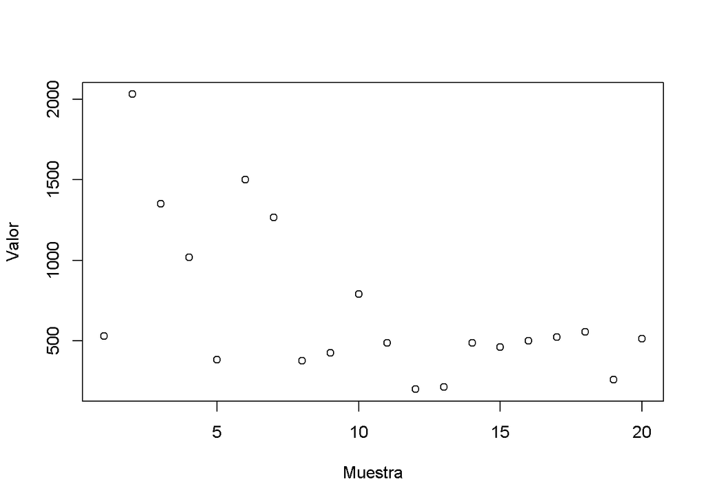

```r
# d) Construir un gráfico de puntos
plot(datos, type = "p", xlab = "Muestra", ylab = "Valor")
```

```r
# e) Encontrar la media recortada al 10%
media_recortada <- mean(datos, trim = 0.1)
cat("La media recortada al 10% es:", media_recortada, "\n")
```

```
## La media recortada al 10% es: 620
```

```r
# f) Encontrar el primer cuartil
q1 <- quantile(datos, 0.25)
cat("El primer cuartil es:", q1, "\n")
```

```
## El primer cuartil es: 414
```

```r
# g) Encontrar el tercer cuartil
q3 <- quantile(datos, 0.75)
cat("El tercer cuartil es:", q3, "\n")
```

```
## El tercer cuartil es: 846.25
```

```r
# h) Encontrar el rango intercuartil
iq_rango <- q3 - q1
cat("El rango intercuartil es:", iq_rango, "\n")
```

```
## El rango intercuartil es: 432.25
```

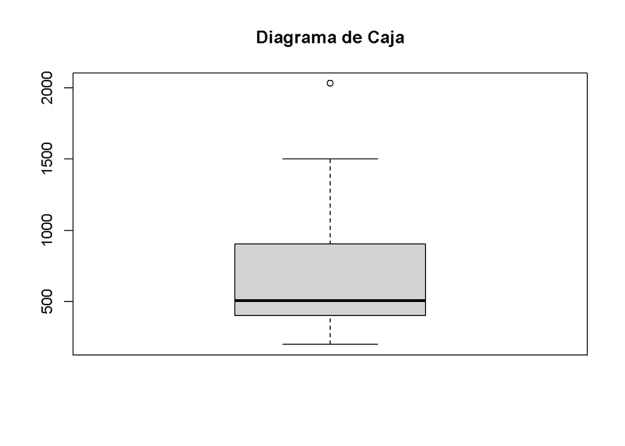

```r
# i) Construir un diagrama de caja
boxplot(datos, main = "Diagrama de Caja")
```

```r
# j) Identificar puntos atípicos
outliers <- boxplot.stats(datos)$out
if (length(outliers) > 0) {
  cat("Los puntos atípicos son:", outliers, "\n")
} else {
  cat("No hay puntos atípicos.\n")
}
```

```
## Los puntos atípicos son: 2030
```

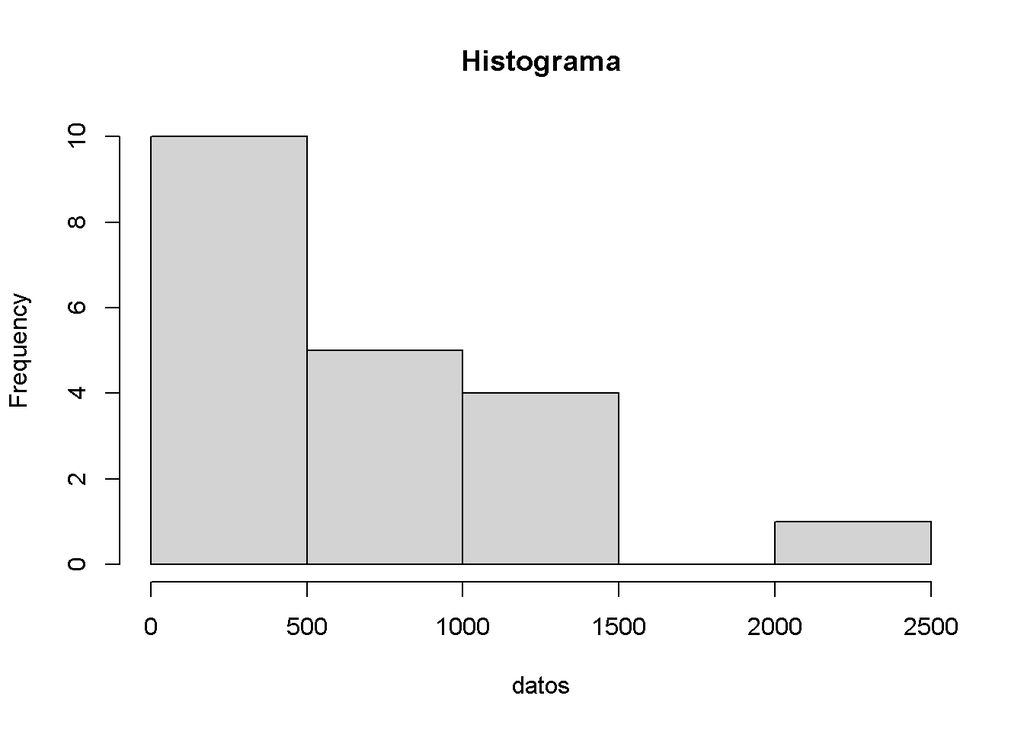

```r
# k) Si se hubiera construido un histograma, ¿estaría sesgado?
hist(datos, main = "Histograma")
```

```r
# El histograma parece estar ligeramente sesgado a la derecha, lo que indica que la distribución de los datos podría estar sesgada a la derecha.
```